# CS PS5

Lindi Li(3460570), Moeka Sakai(3500257)

Exercise 1: Consider the following data generating process with n = 100 observations and p covariates. Initially set the number of predictors p = 3 and X ∼ Np(0, Σ). Σ is the covariance matrix with the variance on the diagonal and small values on the off-diagonal (both values chosen by you). The true coefficients are initially given as β = (0.5, 0.5, −0.5) and the errors are drawn from a normal distribution ε ∼ N (0, σ^2 = 10).

1. Write a function to calculate the ridge regression estimator in closed form (depending on λ) as discussed in the lecture.

generate X -> standardize X -> ridge estimator function: (X’X+lambda*Identical matrix)^(-1)*X’Y).

```r
library(MASS)
set.seed(77)
n<-100
p<-3
mu<-rep(0,p)
sigma<-matrix(c(2,0.01,0.01,0.01,2,0.01,0.01,0.01,2),nrow=p,ncol=p,byrow = TRUE)
beta<-c(0.5,0.5,-0.5)
error<-rnorm(n,0,sqrt(10))
X<-mvrnorm(n,mu,sigma)
X1_sd<-X[,1]/sd(X[,1])
X2_sd<-X[,2]/sd(X[,2])
X3_sd<-X[,3]/sd(X[,3])
X_sd<-cbind(X1_sd,X2_sd,X3_sd)#training sample
Y<-X_sd%*%beta+error
I<-diag(1,p,p)
beta.ridge<-function(lambda,x,y){
  ridge.esti<-solve((t(x)%*%x)+lambda*I)%*%t(x)%*%y
}
```

2. Specify a sequence grid of lambdas containing 100 values and calculate the ridge regression coefficients using the function above. Plot the coefficient paths (λ is on the x-axis) for all three coefficients for one draw.

generate a sequence of 100 lambdas -> name an empty matrix -> loop -> plot: how betas change when lambda increases; betas are all close to zero in the end.

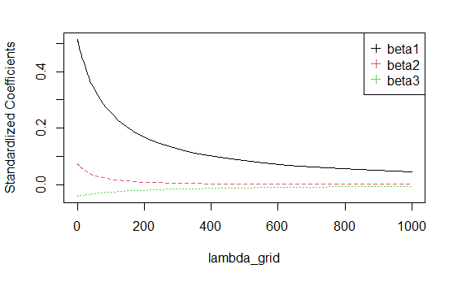

```r
lambda_grid<-10^seq(-2,3,length=100)
beta_ridge<-matrix(NA,nrow=p,ncol=n,byrow=FALSE)
for(i in 1:length(lambda_grid)){
  beta_ridge[,i]<-beta.ridge(lambda_grid[i],X_sd,Y)
}
matplot(lambda_grid,t(beta_ridge),ylab="Standardlized Coefficients",type="l",col=1:3,lwd=1)
legend("topright",legend=c("beta1","beta2","beta3"),col=1:3,cex=1,pch=3)
```

3. Generate a test sample of the same size and calculate the prediction error and the training error for each value of λ and for the OLS estimate. Show your results graphically.

take dataset in problem a as training sample -> generate test sample -> beta_ridge_hat is predicted by training sample -> repeat the loop twice we get test error and training error under ridge regression respectively. calculate OLS estimators using same training sample and test sample -> calculate test error and training error under OLS regression.

```r
#test sample
X_test<-mvrnorm(n,mu,sigma)
X_test1_sd<-X_test[,1]/sd(X_test[,1])
X_test2_sd<-X_test[,2]/sd(X_test[,2])
X_test3_sd<-X_test[,3]/sd(X_test[,3])
X_test_sd<-cbind(X_test1_sd,X_test2_sd,X_test3_sd)
Y_test<-X_test_sd%*%beta+error
test_sample<-data.frame(X_test_sd,Y_test)
beta_ridge_hat<-matrix(NA,nrow=p,ncol=n,byrow=FALSE)#predicted by training sample
Y_test_hat<-matrix(NA,nrow=n,ncol=length(lambda_grid),byrow=FALSE)
prediction_error<-matrix(NA,nrow=1,ncol=length(lambda_grid),byrow=FALSE)
for(i in 1:length(lambda_grid)){
  beta_ridge_hat[,i]<-beta.ridge(lambda_grid[i],X_sd,Y)
  Y_test_hat[,i]<-X_test_sd%*%beta_ridge_hat[,i]
  prediction_error[,i]<-mean((Y_test_hat[,i]-Y_test)^2)
}

#training error
training_sample<-data.frame(X_sd,Y)
Y_hat<-matrix(NA,nrow=n,ncol=length(lambda_grid),byrow=FALSE)
MSE<-matrix(NA,nrow=1,ncol=length(lambda_grid),byrow=FALSE)
for(i in 1:length(lambda_grid)){
  Y_hat[,i]<-X_sd%*%beta_ridge_hat[,i]
  MSE[,i]<-sum((Y-Y_hat[,i])^2)/n
}

#OLS
beta_ols_training<-solve(t(X_sd)%*%X_sd)%*%t(X_sd)%*%Y
Y_ols_traing_hat<-X_sd%*%beta_ols_training
Y_ols_test_hat<-X_test_sd%*%beta_ols_training
MSE_ols<-sum((Y-Y_ols_traing_hat)^2)/n
prediction_error_ols<-mean((Y_ols_test_hat-Y_test)^2)
plot(log(lambda_grid),prediction_error,ylab="Mean Squared Error",lwd=1,col=1,ylim=c(8.5,13))
points(log(lambda_grid),MSE,lwd=1,col=2)
```

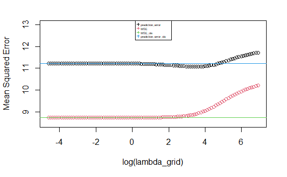

```r
abline(h=c(MSE_ols,prediction_error_ols),col=c(3,4),lwd=c(1,1))
legend("top",legend=c("prediction_error","MSE","MSE_ols","prediction_error_ols"),col=1:4,cex=0.4,pch=3)
```

4. Replace one of the covariates with a constant equal to −10. Show that including the constant (without de-centering first) affects the estimated coefficient paths as discussed in the lecture.

In this case we consider X2 as a constant value, which can be considered as an intercept. Intercept should not be include in penalty term, but in this case we included it. So as lambda increase, all of the betas (absolute value) are decreasing, so is beta2–the line becomes a straight decreasing line.

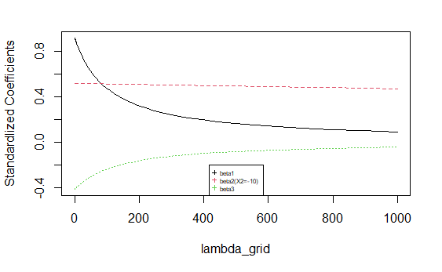

```r
X2_const<-rep(-10,n)
X_withconst<-cbind(X1_sd,X2_const,X3_sd)
Y_withconst<-X_withconst%*%beta+error
beta_ridge_withconst<-matrix(NA,nrow=p,ncol=n,byrow=FALSE)
for(i in 1:length(lambda_grid)){
  beta_ridge_withconst[,i]<-beta.ridge(lambda_grid[i],X_withconst,Y_withconst)
}
matplot(lambda_grid,t(beta_ridge_withconst),ylab="Standardlized Coefficients",type="l",col=1:3,lwd=1)
legend("bottom",legend=c("beta1","beta2(X2=-10)","beta3"),col=1:3,cex=0.5,pch=3)
```

5. Using the glmnet package, determine the optimal lambda from a 10-fold cross-validation procedure.

library “glmnet” -> use “co.out$lambda.min” command. Note: alpha = 0 (ridge regression) alpha = 1 (Lasso) Intercept = FALSE (no intercept)

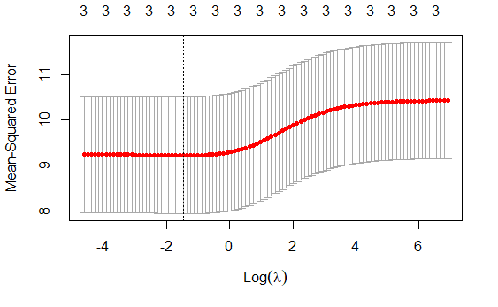

```r
library(glmnet)
cv.out<-cv.glmnet(X_sd,Y,lambda = lambda_grid,alpha=0,intercept=FALSE)
plot(cv.out)
```

```r
best_lambda<-cv.out$lambda.min
best_lambda
```

```
[1] 0.231013
```

Exercise 2 (Stimulation Study) a) Compare the performance of the OLS estimator and the ridge regression estimator in terms of the prediction error for 100 simulation runs.

The smaller the prediction error is, the better the regression performs. Use the best lambda to calculate the ridge regression estimators and compare with OLS in term of prediction error.

```r
#ols
N<-100
p<-3
mu<-rep(0,p)
sigma<-matrix(c(2,0.01,0.01,0.01,2,0.01,0.01,0.01,2),nrow=p,ncol=p,byrow = TRUE)
beta<-c(0.5,0.5,-0.5)
I<-diag(1,p,p)
beta_ols_esti<-matrix(NA,nrow=p,ncol=N,byrow=FALSE)
Y_ols_hat<-matrix(NA,nrow=N,ncol=N)
pred_err_ols<-matrix(NA,nrow=1,ncol=N)
beta_ridge_esti<-matrix(NA,nrow=p,ncol=N,byrow=FALSE)
Y_ridge_hat<-matrix(NA,nrow=N,ncol=N)
pred_err_ridge<-matrix(NA,nrow=1,ncol=N)
for(i in 1:N){
  error<-rnorm(N,0,sqrt(10))
  X<-mvrnorm(N,mu,sigma)
  X1_sd<-X[,1]/sd(X[,1])
  X2_sd<-X[,2]/sd(X[,2])
  X3_sd<-X[,3]/sd(X[,3])
  X_sd<-cbind(X1_sd,X2_sd,X3_sd)
  Y<-X_sd%*%beta+error
  beta_ols_esti[,i]<-solve(t(X_sd)%*%X_sd)%*%t(X_sd)%*%Y
  Y_ols_hat[,i]<-X_sd%*%beta_ols_esti[,i]
  pred_err_ols[,i]<-mean((Y_ols_hat[,i]-Y)^2)
  cv.out1<-cv.glmnet(X_sd,Y,lambda = lambda_grid,alpha=0,intercept=FALSE)
  best_lambda1<-cv.out1$lambda.min
  beta_ridge_esti[,i]<-solve((t(X_sd)%*%X_sd)+best_lambda1*I)%*%t(X_sd)%*%Y
  Y_ridge_hat[,i]<-X_sd%*%beta_ridge_esti[,i]
  pred_err_ridge[,i]<-mean((Y_ridge_hat[,i]-Y)^2)
}
sort(pred_err_ols)
```

```
  [1]  7.093044  7.299160  7.317645  7.325794
  [5]  7.403371  7.437614  7.473444  7.487142
  [9]  7.499866  7.626924  7.681747  7.725260
 [13]  7.798292  7.899308  8.002772  8.016437
 [17]  8.028783  8.050176  8.109889  8.301324
 [21]  8.367360  8.469980  8.499749  8.575502
 [25]  8.575657  8.605280  8.653993  8.710080
 [29]  8.748829  8.753996  8.826226  8.858314
 [33]  8.880706  9.005174  9.008239  9.015841
 [37]  9.030124  9.054273  9.055475  9.135445
 [41]  9.138356  9.141610  9.165509  9.168419
 [45]  9.191538  9.206834  9.225274  9.227136
 [49]  9.266173  9.300628  9.308650  9.320620
 [53]  9.333484  9.353988  9.381211  9.389958
 [57]  9.433340  9.478398  9.529933  9.555146
 [61]  9.572905  9.650805  9.669670  9.697346
 [65]  9.730392  9.768444  9.800030  9.817839
 [69]  9.856520  9.881080  9.917088  9.922211
 [73]  9.949326  9.951202  9.960962  9.977664
 [77]  9.995078 10.013754 10.313335 10.330808
 [81] 10.354142 10.385322 10.402387 10.530068
 [85] 10.635919 10.654729 10.882591 10.932049
 [89] 11.111183 11.210317 11.278293 11.420370
 [93] 11.460780 11.743083 11.819490 11.834467
 [97] 11.895315 12.583245 13.484070 14.582810
```

```r
sort(pred_err_ridge)
```

```
  [1]  7.093123  7.299262  7.318916  7.327378
  [5]  7.403451  7.437840  7.473485  7.487637
  [9]  7.500076  7.626972  7.681818  7.725390
 [13]  7.798342  7.899399  8.002876  8.016992
 [17]  8.028909  8.050247  8.111813  8.367592
 [21]  8.447423  8.470173  8.534290  8.575614
 [25]  8.579816  8.606419  8.654036  8.710123
 [29]  8.754053  8.754581  8.826291  8.880959
 [33]  9.005325  9.008766  9.016167  9.029815
 [37]  9.038460  9.054386  9.055500  9.140568
 [41]  9.165620  9.168593  9.206949  9.225957
 [45]  9.227314  9.267424  9.300726  9.308917
 [49]  9.321450  9.333517  9.354032  9.381316
 [53]  9.389987  9.402490  9.435384  9.449107
 [57]  9.498601  9.514960  9.530097  9.555200
 [61]  9.572973  9.651314  9.670028  9.698028
 [65]  9.731392  9.768529  9.800153  9.881418
 [69]  9.921199  9.922247  9.949481  9.951699
 [73]  9.961569  9.977747  9.995275 10.004494
 [77] 10.013836 10.225143 10.314678 10.330850
 [81] 10.354306 10.385439 10.402892 10.532040
 [85] 10.636343 10.655118 10.932463 10.957713
 [89] 11.113854 11.210450 11.278524 11.423527
 [93] 11.461325 11.744174 11.819567 11.834557
 [97] 11.914286 12.583634 13.484563 14.897977
```

```r
plot(1:100,sort(pred_err_ols),col=4)
lines(1:100,sort(pred_err_ridge),col=2,lwd=1)
```

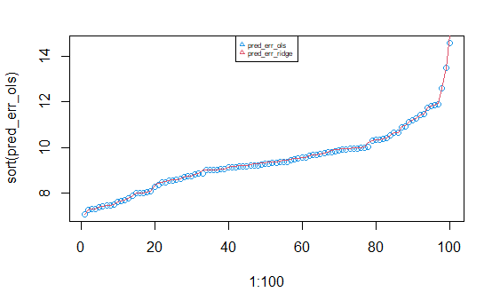

```r
legend("top",legend = c("pred_err_ols","pred_err_ridge"),col=c(4,2),pch=2,cex=0.5)
```

2. Propose a manipulation of the dgp that will improve the ridge regression performance relative to the OLS estimate.

Fix the number of covariates to a certain number (more than 3) -> repeat training and testing process for both OLS and ridge regression.

```r
p<-3
p_b<-8
mu<-rep(0,p)
sigma<-matrix(c(2,0.01,0.01,0.01,2,0.01,0.01,0.01,2),nrow=p,ncol=p,byrow = TRUE)
I_b<-diag(1,p_b,p_b)
beta<-c(0.5,0.5,-0.5)
beta_b<-c(0.5,0.5,-0.5,0.6,0.7,0.1,0.9,0.2)
beta_ols_esti_b_training<-matrix(NA,nrow=p_b,ncol=N,byrow=FALSE)
beta_ridge_esti_b_training<-matrix(NA,nrow=p_b,ncol=N,byrow=FALSE)


#training
for(i in 1:N){
  error<-rnorm(N,0,sqrt(10))
  X<-mvrnorm(N,mu,sigma)
  X1_sd<-X[,1]/sd(X[,1])
  X2_sd<-X[,2]/sd(X[,2])
  X3_sd<-X[,3]/sd(X[,3])
  X4_sd<-rnorm(N,0,1)
  X5_sd<-rnorm(N,0,1)
  X6_sd<-rnorm(N,0,1)
  X7_sd<-runif(N,7-sqrt(3),7+sqrt(3))
  X8_sd<-runif(N,8-sqrt(3),8+sqrt(3))
  X_sd_training<-cbind(X1_sd,X2_sd,X3_sd)
  Y_training<-X_sd_training%*%beta+error
  X_sd_b_training<-cbind(X1_sd,X2_sd,X3_sd,X4_sd,X5_sd,X6_sd,X7_sd,X8_sd)
  beta_ols_esti_b_training[,i]<-solve(t(X_sd_b_training)%*%X_sd_b_training)%*%t(X_sd_b_training)%*%Y_training
  cv.out_b<-cv.glmnet(X_sd_b_training,Y_training,lambda = lambda_grid,alpha=0,intercept=FALSE)
  best_lambda2<-cv.out_b$lambda.min
  beta_ridge_esti_b_training[,i]<-solve((t(X_sd_b_training)%*%X_sd_b_training)+best_lambda2*I_b)%*%t(X_sd_b_training)%*%Y_training
}

#test
Y_ols_hat_b_test<-matrix(NA,nrow=N,ncol=N)
pred_err_ols_b<-matrix(NA,nrow=1,ncol=N)
Y_ridge_hat_b_test<-matrix(NA,nrow=N,ncol=N)
pred_err_ridge_b<-matrix(NA,nrow=1,ncol=N)
for(i in 1:N){
  error<-rnorm(N,0,sqrt(10))
  X<-mvrnorm(N,mu,sigma)
  X1_sd<-X[,1]/sd(X[,1])
  X2_sd<-X[,2]/sd(X[,2])
  X3_sd<-X[,3]/sd(X[,3])
  X4_sd<-rnorm(N,0,1)
  X5_sd<-rnorm(N,0,1)
  X6_sd<-rnorm(N,0,1)
  X7_sd<-runif(N,7-sqrt(3),7+sqrt(3))
  X8_sd<-runif(N,8-sqrt(3),8+sqrt(3))
  X_sd_test<-cbind(X1_sd,X2_sd,X3_sd)
  Y_test2<-X_sd_test%*%beta+error
  X_sd_b_test<-cbind(X1_sd,X2_sd,X3_sd,X4_sd,X5_sd,X6_sd,X7_sd,X8_sd)
  Y_ols_hat_b_test[,i]<-X_sd_b_test%*%beta_ols_esti_b_training[,i]
  pred_err_ols_b[,i]<-mean((Y_ols_hat_b_test[,i]-Y_test2)^2)
  Y_ridge_hat_b_test[,i]<-X_sd_b_test%*%beta_ridge_esti_b_training[,i]
  pred_err_ridge_b[,i]<-mean((Y_ridge_hat_b_test[,i]-Y_test2)^2)
}

plot(1:100,sort(pred_err_ols_b),col=4)
lines(1:100,sort(pred_err_ridge_b),col=2,lwd=1)
```

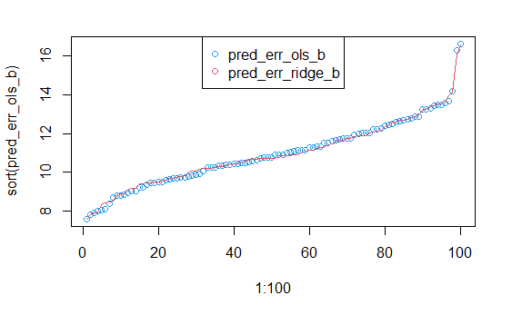

```r
legend("top",legend=c("pred_err_ols_b","pred_err_ridge_b"),col=c(4,2),cex=1,pch=1)
```

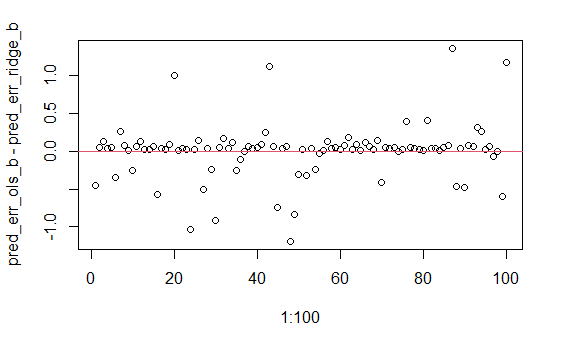

```r
plot(1:100,pred_err_ols_b-pred_err_ridge_b)
abline(h=0,col=2,lwd=1)
```